# L20_HD_Temporal slides

## AERSP 597 - Machine Learning in Aerosapce Engineering

## Lecture 20, High-Dimensional System: Temporal Decomposition

### Instructor: Daning Huang

$$ \newcommand{\bR}{\mathbb{R}} \newcommand{\vf}{\mathbf{f}} \newcommand{\vg}{\mathbf{g}} \newcommand{\vv}{\mathbf{v}} \newcommand{\vw}{\mathbf{w}} \newcommand{\vx}{\mathbf{x}} \newcommand{\vy}{\mathbf{y}} \newcommand{\vA}{\mathbf{A}} \newcommand{\vB}{\mathbf{B}} \newcommand{\vU}{\mathbf{U}} \newcommand{\vV}{\mathbf{V}} \newcommand{\vW}{\mathbf{W}} \newcommand{\vX}{\mathbf{X}} \newcommand{\vtf}{\boldsymbol{\phi}} \newcommand{\vty}{\boldsymbol{\psi}} \newcommand{\vtF}{\boldsymbol{\Phi}} \newcommand{\vtS}{\boldsymbol{\Sigma}} \newcommand{\vtL}{\boldsymbol{\Lambda}} \newcommand{\cF}{\mathcal{F}} \newcommand{\cK}{\mathcal{K}} $$

## TODAY: High-Dimensional System - III

- Issues of spatial decomposition
- Dynamic mode decomposition

### References:

- [DMSC] Chap. 7
- http://dmdbook.com/
- [PyDMD] [Documentation](https://github.com/mathLab/PyDMD/blob/master/tutorials/tutorial_dsweb.pdf)

### Motivation

We first consider a general **non-linear** dynamical system, which is representative of many engineering problems:

$$ \dot{\vx} = \vf(\vx,t,\mu),\quad \vx(0)=\vx_0 $$

with (discrete-time) measurements:

$$ \vy_k=\vg(\vx_k) $$

Why interested in the dynamics:

- System diagnostics: feature extraction and interpretation
- Future state prediction
- Discovery of non-linear dynamics
- Modeling for control applications

We first consider a simple spatially-1D example consisting of

- A low-frequency decaying mode $\omega=-0.05+1.3i$
- A high-frequency growing mode $\omega=0.03+2.8i$
- White noise of constant uniform strength

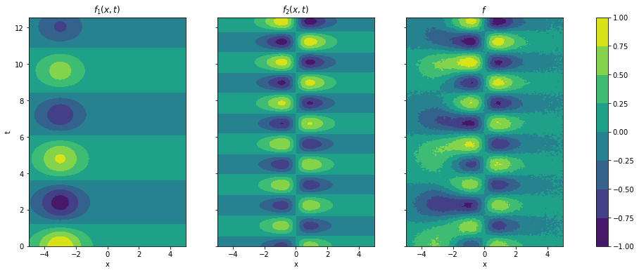

```python
titles = ['$f_1(x,t)$', '$f_2(x,t)$', '$f$']
data = [X1, X2, X]
_=pltContours(xgrid, tgrid, data, titles)
```

Question:

Is it possible to ...

- Extract the modes from the response?
- Recover the frequency of these modes?
- Predict the future responses?

First let's try PCA.

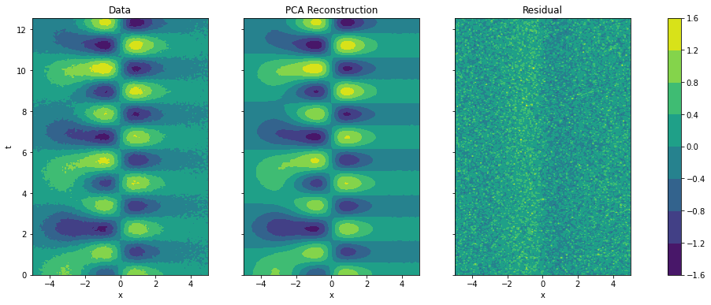

```python
titles = ['Data', 'PCA Reconstruction', 'Residual']
data = [X, X_pca, X-X_pca]
_=pltContours(xgrid, tgrid, data, titles)
```

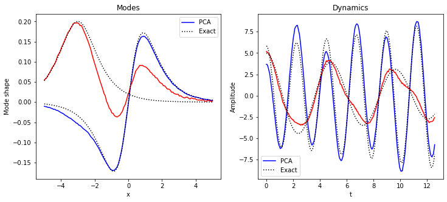

```python
_=pltMD(mod_pca, dyn_pca.T, 'PCA')  # Non-exact modes, non-exact periods
```

Issues with PCA:

- The reconstruction of the original dataset is close to perfect
- However, the modes are mixed up. As a result, the time response of each mode is noisy and contains multiple frequencies.
- Root of the problem: PCA does not account for the order information in data.

> Dynamic Mode Decomposition to the rescue.

## Dynamic Mode Decomposition

### Review: Linear System

In DMD, we approximate the non-linear dynamical system by a low dimensional **linear** system: $$ \dot{\vx}=\bar{\vA}\vx $$ where $\bar{\vA}$ has eigenvalues $\bar{\lambda}=\zeta+\omega i$ and eigenvectors $\vtf$.

Then the solution is determined from the initial condition $\vx(0)=\vx_0$, $$ \vx=\sum_{i=1}^n b_i \vtf_i e^{\bar{\lambda}_i t} $$ where $b_i=\vtf_i^T\vx_0$

But typically the state measurement occurs at discrete time $\vx_j=\vx(t_j)$, with a time step size $\Delta t$, so one has a discrete linear system, $$ \vx_{k+1} = \vA \vx_k $$ where $\vA=\exp(\vA\Delta t)$, and $\vA$ has the same eigenvectors $\vtf$ as $\bar{\vA}$, but the eigenvalues become, $$ \lambda = \exp(\bar{\lambda}\Delta t),\quad \mathrm{or},\quad \bar{\lambda} = \frac{\log|\lambda|}{\Delta t} + \frac{\mathrm{Arg}(\lambda)}{\Delta t} i $$ And the solution given $\vx(0)=\vx_0$ is now written as, $$ \vx_{k+1}=\sum_{i=1}^n b_i \lambda_i^{k+1} \vtf_i $$

### Review: Linear Stability

The eigenvalues determine the stability of the modes, i.e. whether the response decays or grows in time. Specifically, for the continuous case, we check $\zeta=Re(\bar{\lambda})$; for the discrete case, we check $|\lambda|$:

- $\zeta<0$, or $|\lambda|<1$: Decaying response, hence stable.
- $\zeta=0$, or $|\lambda|=1$: Neutrally stable.
- $\zeta>0$, or $|\lambda|>1$: Growing response, hence unstable.

### 2D Example

[figure not shown]

The eigenvalues: $\lambda_{1,2}=\frac{1}{2}\left( p\pm\sqrt\Delta \right)$

Be careful with the boundaries - what happens when

- $q=0$: $\lambda_1=p$ and $\lambda_2=0$
  - One direction is "unresponsive"
- $\Delta=0$: $\lambda_{1,2}=p/2$
  - Two identical eigenvalues - do we always get two different eigenvectors?

We shall explore more later in *nonmodal analysis* (if time permits)

### Setting up the Temporal decomposition

Now assume full-state measurement: $\vx_j=\vx(t_j)$

Assemble $m$ measurements into the following:

$$ \begin{align} \vX &= [\vx_1 | \vx_2 | \cdots | \vx_{m-1}] \\ \vX^1 &= [\vx_2 | \vx_3 | \cdots | \vx_m] \end{align} $$

If the system is linear, there is a discrete-time system matrix satisfying $$ \vX^1 = \vA\vX $$

This is a least squares problem, and the solution is $$ \vA = \vX^1 \vX^+ $$ where $\vX^+$ is the pseudo-inverse.

> Again, be careful this $\vA$ is different from the $\bar{\vA}$ in the continuous system.

### Algorithm

To find $\vA$, and the associated modes and eigenvalues, we carry out the following steps:

- Step 1: Rank-r truncation $$ \vX=\vU_r\vtS_r\vV_r^* $$
- Step 2: System matrix $$ \vA = \vX^1\vV_r\vtS_r^{-1}\vU_r^* \equiv \vB\vU_r^* $$ and the reduced system matrix $$ \tilde\vA = \vU_r^*\vA\vU_r = \vU_r^*\vB $$
- Step 3: Reduced eigenvalue problem $$ \tilde\vA\vw = \lambda\vw $$
- Step 4: Eigensystem recovery

### Recovering Eigensystem

There are two ways to find the modes $\vtf_i$ associated with the original system. One is approximate, and the other exact.

- Version 1: Projected DMD, $\vtf_i$ is a linear combination of left singular vectors of $\vX$ $$ \vU_r^*\vA\vU_r\vw = \lambda\vw \quad\Rightarrow\quad (\vU_r\vU_r^*)\vA(\vU_r\vw) = (\vU_r\vU_r^*)\lambda(\vU_r\vw) $$ So $\hat\vtf=\vU_r\vw$
- Version 2: Exact DMD, the definition involves **both** $\vX$ and $\vX^1$, i.e. all data samples. $$ \tilde\vA\vw = \lambda\vw \quad\Rightarrow\quad \vB\vU_r^*\vB\vw = \lambda\vB\vw \quad\Rightarrow\quad \vA(\vB\vw)=\lambda(\vB\vw) $$ So $\vtf=\frac{1}{\lambda}\vB\vw$

Comparing the two modes: $$ \vU_r\vU_r^*\vtf = \frac{1}{\lambda}\vU_r\vU_r^*\vB\vw = \frac{1}{\lambda}\vU_r\tilde\vA\vw = \vU_r\vw = \hat{\vtf} $$ So $\hat{\vtf}$ is the projection of $\vtf$ onto the $\vU_r$ space. Potential information loss due to projection!

Finally, the eigenvalues $\lambda$ of $\vA$ (discrete system) can be converted back to $\bar{\lambda}$ of $\bar{\vA}$ (continuous system) to identify the damping and frequency associated with the DMD modes $\vtf$.

### DMD v.s. ERA

In terms of system identification, there are classical algorithms like the Eigensystem Realization Algorithm (ERA) and the Observer Kalman Filter Identification (OKID).

[figure not shown]

- ERA/OKID is for systems with higher dimensions than number of observables/measurements.
- DMD etc. is for systems with many observables/measurements with lower dimensional dynamics.
- ERA takes care of control input, while DMD cannot (but DMD with control, [DMDc](https://arxiv.org/pdf/1409.6358.pdf), can)

### DMD v.s. EMD

Another commonly used approach is from signal processing, called [Empirical Mode Decomposition (EMD)](https://en.wikipedia.org/wiki/Hilbert%E2%80%93Huang_transform), or., e.g., its more recent variant, [Variational Mode Decomposition (VMD)](https://ieeexplore.ieee.org/document/6655981).

- Recursively decomposes a signal into different modes of unknown but separate spectral bands
- Suitable for data that is nonstationary and nonlinear.
- But mainly for 1D data (though there are multi-dimensional extensions, such as this work on [unsteady aerodynamics](https://ieeexplore.ieee.org/abstract/document/8447300))

[figure not shown]

### Back to our example

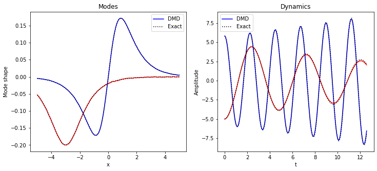

```python
f, ax = plt.subplots(ncols=2, figsize=(12,5))
ax[0].plot(x, dmd.modes[:,0].real, 'b-', label='DMD')
ax[0].plot(x, dmd.modes[:,1].real, 'r-')
ax[0].plot(x, -M1.real, 'k:', label='Exact')
ax[0].plot(x, M2.real, 'k:')
ax[0].legend()
ax[0].set_xlabel('x')
ax[0].set_ylabel('Mode shape')
ax[0].set_title('Modes')

ax[1].plot(t, dmd.dynamics[0].real, 'b-', label='DMD')
ax[1].plot(t, dmd.dynamics[1].real, 'r-')
ax[1].plot(t, np.real(D2), 'k:', label='Exact')
ax[1].plot(t, np.real(-D1), 'k:')
ax[1].legend()
ax[1].set_xlabel('t')
ax[1].set_ylabel('Amplitude')
_=ax[1].set_title('Dynamics')
```

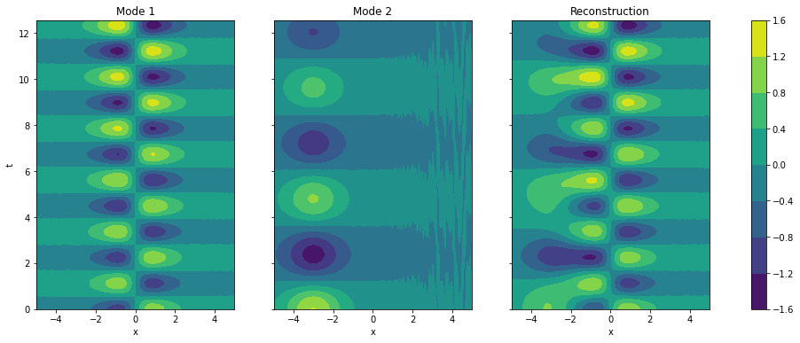

```python
titles = ['Mode 1', 'Mode 2', 'Reconstruction']
data = [dmd.dynamics[0].reshape(-1, 1).dot(dmd.modes[:,0].reshape(1, -1)),
        dmd.dynamics[1].reshape(-1, 1).dot(dmd.modes[:,1].reshape(1, -1)),
        dmd.reconstructed_data.T]
_=pltContours(xgrid, tgrid, data, titles)
```

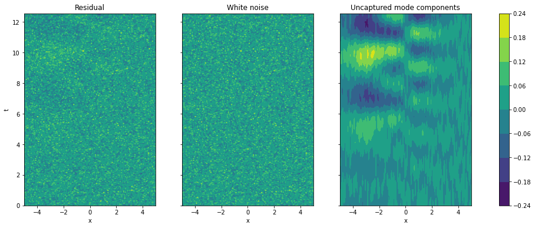

```python
titles = ['Residual', 'White noise', 'Uncaptured mode components']
data = [(X-dmd.reconstructed_data.T).real,
        Xn,
        (X-dmd.reconstructed_data.T-Xn).real]
_=pltContours(xgrid, tgrid, data, titles)
```

### Pondering this example

We applied DMD to **complex** data, but only check the **real** part of reconstructed data.

- What if we directly apply DMD to the real part of the dataset?

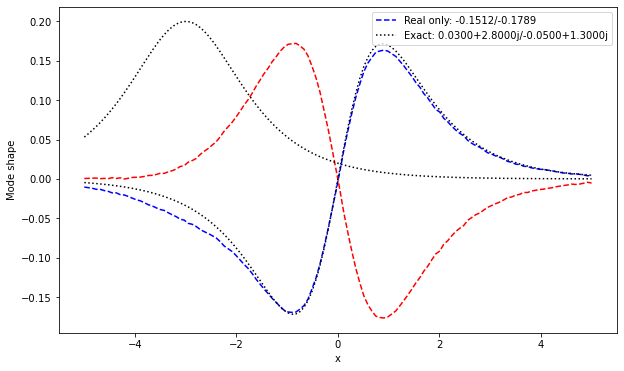

```python
f = plt.figure(figsize=(10,6))
plt.plot(x, dmd_real.modes[:,0], 'b--',
         label='Real only: {0:5.4f}/{1:5.4f}'.format(*_eig(dmd_real.eigs)))
plt.plot(x, dmd_real.modes[:,1], 'r--')
plt.plot(x, M1.real, 'k:',
         label='Exact: {0:5.4f}/{1:5.4f}'.format(w2, w1))
plt.plot(x, M2.real, 'k:')
plt.legend()
plt.xlabel('x')
_=plt.ylabel('Mode shape')
```

> The real-only DMD failed like PCA, but for a different reason.
- Consider oscillation at one frequency (with or w/o damping)
  - Requires a **conjugate** pair of two modes, i.e. modes $\boldsymbol{\phi}_{1,2}=\mathbf{u}\pm\mathbf{v}i$ with eigenvalues $\lambda_{1,2}=\zeta\pm\omega i$.
  - The conjugacy can be interpreted as phase information, or "displacement v.s. velocity"
  - The algorithm needs to **"see"** both modes in the observation - so the imag part is necessary.
- If one really wants to work with DMD within the real domain, then
  - A new dataset has to be formed by stacking the real and imag parts: $\vX=[\vU^T\ \vV^T]^T$
  - Number of modes requested should be doubled: One **pair** of (conjugate) modes correspond to one exact complex mode
- Alternatively, one could apply DMD to the real part only with a shifting, i.e., higher-order DMD
  - New snapshots with $m$ shifts $\vy_k^T=[\vx_{k}^T, \vx_{k-1}^T, \cdots, \vx_{k-m}^T]$.
  - There will be $(m-1)$ fewer samples.
  - It essentially tries to reconstruct the missing phase/velocity data from a few snapshots within a time window.
  - This technique is called **Time Delayed Embedding**, cf. [Taken's theorem](https://en.wikipedia.org/wiki/Takens%27s_theorem)

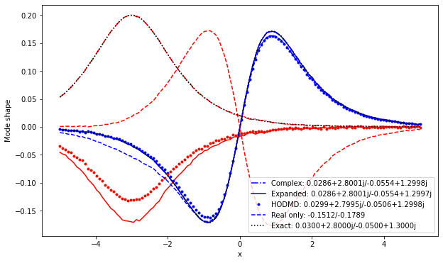

```python
f = plt.figure(figsize=(10,6))
plt.plot(x, _nrm(dmd.modes[:,0].real), 'b-.', label='Complex: {0:5.4f}/{1:5.4f}'.format(*_eig(dmd.eigs)))
plt.plot(x, -_nrm(dmd.modes[:,1].real), 'r-.')
plt.plot(x, -_nrm(dmd_expd.modes[:128,0]), 'b-', label='Expanded: {0:5.4f}/{2:5.4f}'.format(*_eig(dmd_expd.eigs)))
plt.plot(x, _nrm(dmd_expd.modes[:128,2]), 'r-')
plt.plot(x, -_nrm(hodmd.modes[:,0]), 'b.', label='HODMD: {0:5.4f}/{2:5.4f}'.format(*_eig(hodmd.eigs)))
plt.plot(x, -_nrm(hodmd.modes[:,2]), 'r.')
plt.plot(x, dmd_real.modes[:,0], 'b--', label='Real only: {0:5.4f}/{1:5.4f}'.format(*_eig(dmd_real.eigs)))
plt.plot(x, dmd_real.modes[:,1], 'r--')
plt.plot(x, M1.real, 'k:', label='Exact: {0:5.4f}/{1:5.4f}'.format(w2, w1))
plt.plot(x, M2.real, 'k:')
plt.legend()
plt.xlabel('x')
_=plt.ylabel('Mode shape')
```